# DeepLearning

Ryan Gallagher

2025-04-09

# Single Layer Neural Network

## Hitters Data Setup

Our goal will be to fit a Single Layer Neural Network to our Hitters dataset. We will start by loading and cleaning this data.

```r
library(ISLR2)
# Clean and export the dataset for Python
Hitters_clean = na.omit(Hitters)

# We will fit a linear regression for comparison as well and save those results
x = scale(model.matrix(Salary ~ . - 1, data = Hitters_clean))
y = Hitters_clean$Salary

Gitters = na.omit(Hitters)
n = nrow(Gitters)
ntest = trunc(n / 3)
testid = sample(1:n, ntest)
lfit = lm(Salary ~ ., data = Gitters[-testid, ])
lpred = predict(lfit, Gitters[testid, ])
mean(abs(lpred - Gitters$Salary[testid]))
```

```
## [1] 230.2947
```

```r
# Save as CSV for Python to read
write.csv(x, "~/Desktop/Personal/UWM/Lecture 10/x.csv", row.names = FALSE)
write.csv(y, "~/Desktop/Personal/UWM/Lecture 10/y.csv", row.names = FALSE)


## CREATE VIRTUAL ENV
#library(reticulate)
# Create a new virtual environment
#virtualenv_create("r-keras")

# Install necessary packages
#virtualenv_install("r-keras", packages = c(
#  "numpy", "pandas", "matplotlib", "scikit-learn", "tensorflow"
#))

# Load env
#use_virtualenv("r-keras", required = TRUE)
```

## Neural Network in Python (via Keras)

We can write python code in RMarkdown as well. We will run our analysis in Python since the R tools used for tensorflow are out dated.

Our model function defines `epochs` which are **loops over our data** and our `activation function` which decides if a neuron should be activated or not. This activation function is set to `relu` or **Rectified Linear Unit**.

We also have a **dropout parameter** which is tunable to prevent overfitting. Here for a `dropout = 0.4`, we are saying that `40%` of the activtations from the prvious layer are randomly set to zero.

We also have `batch_size` which tell our epochs how many samples to. Small batches and large batches have trade-offs. Batch size of 32 is a popular default.

```python
import numpy as np
import pandas as pd
from sklearn.model_selection import train_test_split
from tensorflow import keras
from tensorflow.keras import layers

# Load preprocessed data
x = pd.read_csv("x.csv").values.astype('float32')
y = pd.read_csv("y.csv").values.astype('float32').reshape(-1)

# Train/test split
x_train, x_test, y_train, y_test = train_test_split(x, y, test_size=0.33, random_state=42)

# Build model
model = keras.Sequential([
    layers.Dense(50, activation='relu', input_shape=(x.shape[1],)),
    layers.Dropout(0.4),
    layers.Dense(1)  # regression output
])
```

```python
model.compile(optimizer='rmsprop', loss='mse', metrics=['mae'])

# Train model
history = model.fit(
    x_train, y_train,
    epochs=1500,
    batch_size=32,
    validation_data=(x_test, y_test),
    verbose=0  # Suppress console spam
)

# Evaluate
test_mae = model.evaluate(x_test, y_test, verbose=0)[1]
print(f"Test MAE: {test_mae:.2f}")
```

```
## Test MAE: 253.35
```

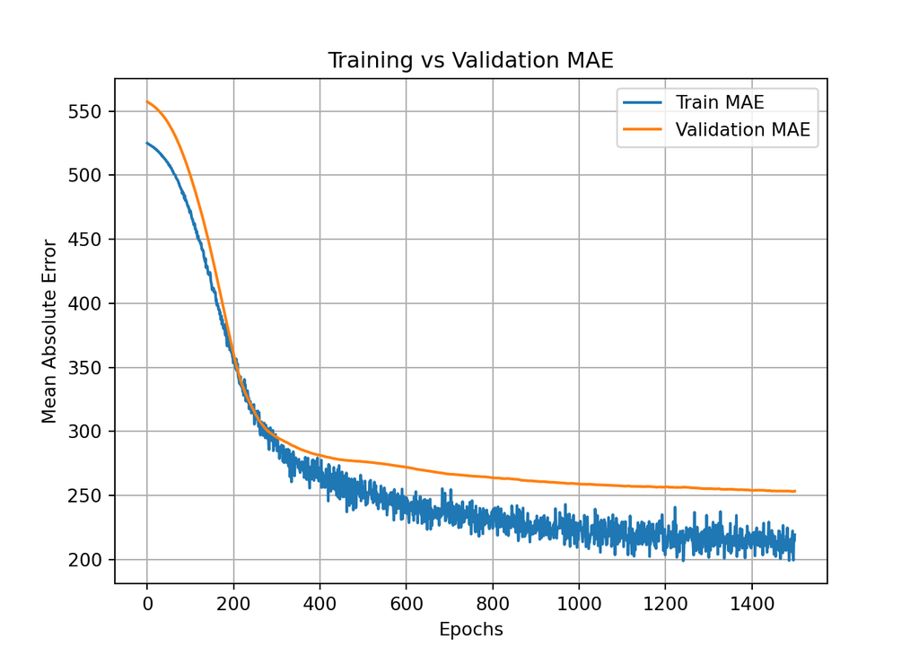

```python
import matplotlib.pyplot as plt

plt.plot(history.history['mae'], label='Train MAE')
plt.plot(history.history['val_mae'], label='Validation MAE')
plt.xlabel("Epochs")
plt.ylabel("Mean Absolute Error")
plt.title("Training vs Validation MAE")
plt.legend()
plt.grid(True)
plt.show()
```

# Multilayer Neural Network

## Load the MNIST dataset

This dataset consists of handwritten digits. The goal of our model is to predict what digits those drawing represent.

```python
# Load the MNIST digit dataset (60,000 train, 10,000 test)
mnist = keras.datasets.mnist
(x_train, y_train), (x_test, y_test) = mnist.load_data()

# Preprocess the data
# Flatten 28x28 images to 784-length vectors
x_train = x_train.reshape(-1, 784).astype("float32") / 255.0
x_test = x_test.reshape(-1, 784).astype("float32") / 255.0

# One-hot encode the labels for softmax classification
y_train_cat = keras.utils.to_categorical(y_train, 10)
y_test_cat = keras.utils.to_categorical(y_test, 10)
```

## Define the Multilayer Neural Network

We will use the `relu` activation function again. We will use the 40% dropout for the first layer, and 30% dropout for the second layer. Finally, we will use the `softmax` function for the final layer.

```python
model = keras.Sequential([
    layers.Dense(256, activation="relu", input_shape=(784,)),
    layers.Dropout(0.4),  # Drop 40% of neurons during training for regularization
    layers.Dense(128, activation="relu"),
    layers.Dropout(0.3),
    layers.Dense(10, activation="softmax")  # Final layer: 10 classes for digits 0-9
])
```

## Compile the Model

```python
model.compile(
    optimizer="rmsprop",
    loss="categorical_crossentropy",
    metrics=["accuracy"]
)
```

## Train the Model

We will use 30 epochs (less since we have so much more data to loop through). With a reasonably high batch size of 128. We will use 20% of our data for validation.

```python
history = model.fit(
    x_train, y_train_cat,
    epochs=30,
    batch_size=128,
    validation_split=0.2,
    verbose=0  # suppress batch logs for cleaner RMarkdown output
)
```

## Plot the accuracy and get evaluation metrics

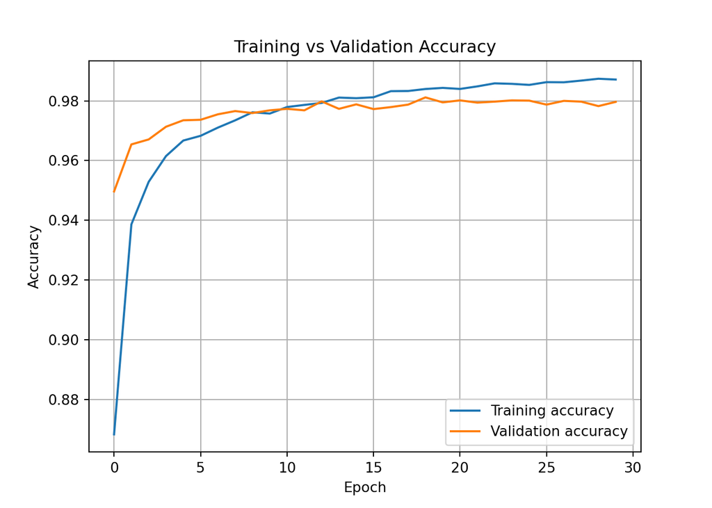

```python
# Plot training and validation accuracy
plt.plot(history.history["accuracy"], label="Training accuracy")
plt.plot(history.history["val_accuracy"], label="Validation accuracy")
plt.title("Training vs Validation Accuracy")
plt.xlabel("Epoch")
plt.ylabel("Accuracy")
plt.legend()
plt.grid(True)
plt.show()
```

```python
# Evaluate the model on the test data
test_loss, test_acc = model.evaluate(x_test, y_test_cat, verbose=0)
print(f"Test Accuracy: {test_acc:.4f}")
```

```
## Test Accuracy: 0.9812
```

```python
pred_classes = model.predict(x_test).argmax(axis=1)
```

```
##   1/313 ━━━━━━━━━━━━━━━━━━━━ 5s 18ms/step150/313 ━━━━━━━━━━━━━━━━━━━━ 0s 337us/step306/313 ━━━━━━━━━━━━━━━━━━━━ 0s 329us/step313/313 ━━━━━━━━━━━━━━━━━━━━ 0s 381us/step
```

```python
#manual_acc = accuracy_score(y_test, pred_classes)
```

## Visualize the predictions by image

```python
# Select 16 random test digits to visualize
num_images = 16
indices = np.random.choice(len(x_test), num_images, replace=False)
images = x_test[indices].reshape(-1, 28, 28)
true_labels = y_test[indices]
predicted_labels = pred_classes[indices]

# Plot images with predicted and true labels
plt.figure(figsize=(10, 10))
for i in range(num_images):
    plt.subplot(4, 4, i + 1)
    plt.imshow(images[i], cmap="gray")
    plt.title(f"Pred: {predicted_labels[i]}, True: {true_labels[i]}")
    plt.axis("off")
```

[output not shown]

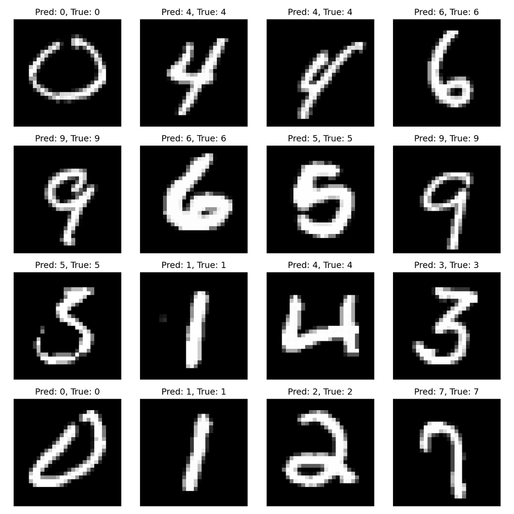

```python
plt.tight_layout()
plt.suptitle("MNIST Predictions vs True Labels", y=1.05)
plt.show()
```